# Forecasting Patient Attendance for Appointments _A Logistic Regression Approach

## An Analysis of Missed Patient Appointments in Brazil in the Year 2016

```
                                              by

                                    Jacktone Etemesi

                                Phone: +254708578181

                            email: jacktoneetemesi1@gmail.com
```

## *Introduction*

This project involves an analysis of patient records in Brazil to determine the attendance rates of scheduled medical appointments. The aim of the project is to address the following research questions:

```
Q1. In general, what sex is associated with the highest no-show rate?

Q2. What age bracket is associated with the highest number of missed appointments?

Q3. What day of the week registered the highest number of missed appointments?

Q4. What are the five leading hospital neighborhoods in terms of alcoholism cases? How do these neighborhoods compare in terms of missed patient appointments?

Q5. Is there a correlation between the number of days a patient in a given region has to wait for an appointment and the number of missed appointments in that particular region?

Q6. Can a model be built to predict if a patient will show up for an appointment?
```

The dataset used for this analysis consists of information from 110,527 medical appointments in Brazil. Each row contains various characteristics about the patient.

The dataset comprises 14 columns, which are described as follows:

```
1. PatientId: The unique ID assigned to each patient.
2. AppointmentID: The unique ID assigned to each appointment.
3. Gender: The gender of the patient.
4. ScheduledDay: The date when the patient scheduled the appointment.
5. AppointmentDay: The date when the patient is expected to attend the appointment.
6. Age: The age of the patient.
7. Neighbourhood: The location where the appointment takes place.
8. Scholarship: Indicates whether the patient is enrolled in the Brazilian welfare program.
9. Hipertension: Indicates whether the patient has hypertension.
10. Diabetes: Indicates whether the patient has diabetes.
11. Alcoholism: Indicates whether the patient has alcoholism.
12. Handcap: The number of handicaps the patient has.
13. SMS_received: Indicates whether the patient received an SMS reminder for the appointment.
14. No-show: Indicates whether the patient showed up for the appointment or not.
```

By analyzing these variables, we can gain insights into the factors that contribute to missed patient appointments in Brazil and potentially develop predictive models to enhance appointment attendance rates.

### **Assumptions:**

This analysis is based on the following assumptions:

```
1. All patients prefer going to hospitals within their neighborhoods. With this assumption, we consider the hospital neighborhood to be the same as that of patients who scheduled for an appointment in that particular hospital neighborhood.

2. We assume that all missed appointments were solely due to causes related to the patient, such as personal reasons or forgetting the appointment. We do not consider appointments that were canceled or terminated by the hospitals.

3. We assume that patients missed their appointments for reasons other than death. This analysis focuses on the factors that contribute to missed appointments, excluding cases where patients were unable to attend due to severe circumstances like death.
```

## Step 1: Data Wrangling

### *Importing relevant Libraries for Data cleaning, Exploration and Visualization*

```python
import numpy as np
import pandas as pd
import matplotlib.pyplot as plt
import seaborn as sns
from datetime import datetime
from plotly import __version__
from plotly.offline import download_plotlyjs, init_notebook_mode, plot, iplot
import cufflinks as cf
#for notebook
init_notebook_mode(connected=True)
# For offline use
cf.go_offline()
import plotly.express as px
%matplotlib inline

#Loading our dataset
df=pd.read_csv('noshowappointments-kagglev2-may-2016.csv')
```

### *Checking for the shape of our dataset in terms of number of rows and columns*

```python
df.shape
```

```
(110527, 14)
```

*The DataFrame used in this analysis consists of 110,527 rows and 14 columns.*

```python
df.head()
```

|  | PatientId | AppointmentID | Gender | ScheduledDay | AppointmentDay | Age | Neighbourhood | Scholarship | Hipertension | Diabetes | Alcoholism | Handcap | SMS_received | No-show |
| --- | --- | --- | --- | --- | --- | --- | --- | --- | --- | --- | --- | --- | --- | --- |
| 0 | 2.987250e+13 | 5642903 | F | 2016-04-29T18:38:08Z | 2016-04-29T00:00:00Z | 62 | JARDIM DA PENHA | 0 | 1 | 0 | 0 | 0 | 0 | No |
| 1 | 5.589978e+14 | 5642503 | M | 2016-04-29T16:08:27Z | 2016-04-29T00:00:00Z | 56 | JARDIM DA PENHA | 0 | 0 | 0 | 0 | 0 | 0 | No |
| 2 | 4.262962e+12 | 5642549 | F | 2016-04-29T16:19:04Z | 2016-04-29T00:00:00Z | 62 | MATA DA PRAIA | 0 | 0 | 0 | 0 | 0 | 0 | No |
| 3 | 8.679512e+11 | 5642828 | F | 2016-04-29T17:29:31Z | 2016-04-29T00:00:00Z | 8 | PONTAL DE CAMBURI | 0 | 0 | 0 | 0 | 0 | 0 | No |
| 4 | 8.841186e+12 | 5642494 | F | 2016-04-29T16:07:23Z | 2016-04-29T00:00:00Z | 56 | JARDIM DA PENHA | 0 | 1 | 1 | 0 | 0 | 0 | No |

### *Checking for columns and their data types*

```python
df.info()
```

```
<class 'pandas.core.frame.DataFrame'>
RangeIndex: 110527 entries, 0 to 110526
Data columns (total 14 columns):
 #   Column          Non-Null Count   Dtype
---  ------          --------------   -----
 0   PatientId       110527 non-null  float64
 1   AppointmentID   110527 non-null  int64
 2   Gender          110527 non-null  object
 3   ScheduledDay    110527 non-null  object
 4   AppointmentDay  110527 non-null  object
 5   Age             110527 non-null  int64
 6   Neighbourhood   110527 non-null  object
 7   Scholarship     110527 non-null  int64
 8   Hipertension    110527 non-null  int64
 9   Diabetes        110527 non-null  int64
 10  Alcoholism      110527 non-null  int64
 11  Handcap         110527 non-null  int64
 12  SMS_received    110527 non-null  int64
 13  No-show         110527 non-null  object
dtypes: float64(1), int64(8), object(5)
memory usage: 11.8+ MB
```

### *Assessing Statistical Summary of Our Data*

```python
df.describe()
```

|  | PatientId | AppointmentID | Age | Scholarship | Hipertension | Diabetes | Alcoholism | Handcap | SMS_received |
| --- | --- | --- | --- | --- | --- | --- | --- | --- | --- |
| count | 1.105270e+05 | 1.105270e+05 | 110527.000000 | 110527.000000 | 110527.000000 | 110527.000000 | 110527.000000 | 110527.000000 | 110527.000000 |
| mean | 1.474963e+14 | 5.675305e+06 | 37.088874 | 0.098266 | 0.197246 | 0.071865 | 0.030400 | 0.022248 | 0.321026 |
| std | 2.560949e+14 | 7.129575e+04 | 23.110205 | 0.297675 | 0.397921 | 0.258265 | 0.171686 | 0.161543 | 0.466873 |
| min | 3.921784e+04 | 5.030230e+06 | -1.000000 | 0.000000 | 0.000000 | 0.000000 | 0.000000 | 0.000000 | 0.000000 |
| 25% | 4.172614e+12 | 5.640286e+06 | 18.000000 | 0.000000 | 0.000000 | 0.000000 | 0.000000 | 0.000000 | 0.000000 |
| 50% | 3.173184e+13 | 5.680573e+06 | 37.000000 | 0.000000 | 0.000000 | 0.000000 | 0.000000 | 0.000000 | 0.000000 |
| 75% | 9.439172e+13 | 5.725524e+06 | 55.000000 | 0.000000 | 0.000000 | 0.000000 | 0.000000 | 0.000000 | 1.000000 |
| max | 9.999816e+14 | 5.790484e+06 | 115.000000 | 1.000000 | 1.000000 | 1.000000 | 1.000000 | 4.000000 | 1.000000 |

*The following issues within our columns need to be addressed.*

```
i. Column names need to be changed to lowercase
ii. ScheduleDay and AppointmentDay columns need to be converted to datetime dtype
iii. There is a negative value in the Age column
```

## Step 2: Data Cleaning

### *i. Changing column names to lowercase letters*

```python
for col in df.columns:
    df.rename(columns=lambda x:x.lower(),inplace=True)
df.head(2)
```

|  | patientid | appointmentid | gender | scheduledday | appointmentday | age | neighbourhood | scholarship | hipertension | diabetes | alcoholism | handcap | sms_received | no-show |
| --- | --- | --- | --- | --- | --- | --- | --- | --- | --- | --- | --- | --- | --- | --- |
| 0 | 2.987250e+13 | 5642903 | F | 2016-04-29T18:38:08Z | 2016-04-29T00:00:00Z | 62 | JARDIM DA PENHA | 0 | 1 | 0 | 0 | 0 | 0 | No |
| 1 | 5.589978e+14 | 5642503 | M | 2016-04-29T16:08:27Z | 2016-04-29T00:00:00Z | 56 | JARDIM DA PENHA | 0 | 0 | 0 | 0 | 0 | 0 | No |

### *ii. Converting scheduledday and appointmentday columns into datetime dtype*

```python
# Creating a function to iterate over a list of given columns in the dataFrame and converting their data types into Datetime
def todtime(df,cols):
    for i in cols:
        df[i]=pd.to_datetime(df[i],utc=True)
    return df

todtime(df,['scheduledday','appointmentday']) #calling the function
df[['scheduledday','appointmentday']].dtypes #checking datatypes
```

```
scheduledday      datetime64[ns, UTC]
appointmentday    datetime64[ns, UTC]
dtype: object
```

### *iii. Removing negative values from the age columns*

```python
df[df['age']<0]
```

|  | patientid | appointmentid | gender | scheduledday | appointmentday | age | neighbourhood | scholarship | hipertension | diabetes | alcoholism | handcap | sms_received | no-show |
| --- | --- | --- | --- | --- | --- | --- | --- | --- | --- | --- | --- | --- | --- | --- |
| 99832 | 4.659432e+14 | 5775010 | F | 2016-06-06 08:58:13+00:00 | 2016-06-06 00:00:00+00:00 | -1 | ROMÃO | 0 | 0 | 0 | 0 | 0 | 0 | No |

*one observation has a negative value in the age column. Since age values should be positive integers, it is unclear why this negative value was recorded. To ensure the integrity of our analysis and prevent potential bias in our model, it is advisable to remove this particular row from the dataset.*

```python
df.drop(index=99832,axis=0,inplace=True) # Deleting the row with a negative age value from our dataset.
```

```python
df[df['age']<0]
```

|  | patientid | appointmentid | gender | scheduledday | appointmentday | age | neighbourhood | scholarship | hipertension | diabetes | alcoholism | handcap | sms_received | no-show |
| --- | --- | --- | --- | --- | --- | --- | --- | --- | --- | --- | --- | --- | --- | --- |

### *iv. Checking for Missing Values*

```python
df.isnull().sum().sum()
```

```
0
```

*Our dataset does not have any missing values.*

### *v. Checking for duplicate values*

```python
df.duplicated().sum()
```

```
0
```

*Our dataset does not have any duplicate entries.*

### *vi. Checking for Outliers*

*Under this section, we will check for outliers within the age column, which is the only continuous numerical variable in our dataset. To begin, we will examine the statistical summary of the age column.*

```python
df['age'].describe()
```

```
count    110526.000000
mean         37.089219
std          23.110026
min           0.000000
25%          18.000000
50%          37.000000
75%          55.000000
max         115.000000
Name: age, dtype: float64
```

*We observe that the youngest patient had less than a year, while the oldest patient was 115 years old. The majority of the patients were approximately 37.10 years old, with a standard deviation of 23.11 years.*

*We will now proceed to visualize the distribution of patient ages using a histogram and then create a boxplot to investigate the presence of outliers within our dataset. The presence of outliers can potentially skew our model and affect its performance.*

```python
df['age'].iplot(kind='hist', title='Distribution of Patient Ages', xTitle='Age',yTitle='No of patients',color='blue')
```

[interactive chart not shown]

*We will perform the Shapiro-Wilk test to determine if our data follows a normal distribution. The Shapiro-Wilk test is a statistical test used to assess the normality of a dataset. It tests the null hypothesis that the data is normally distributed. If the p-value obtained from the test is greater than a chosen significance level (e.g., 0.05), we can conclude that there is no significant evidence to reject the null hypothesis and that our data can be assumed to be normally distributed.*

```python
from scipy.stats import shapiro
shapiro(df['age'].sample(5000,random_state=101)) #eliminate random state to test out other samples
```

```
ShapiroResult(statistic=0.9712730646133423, pvalue=1.5518840684527575e-30)
```

NB: The Shapiro-Wilk test was conducted on a random sample of 5,000 records. It is worth noting that the accuracy of the p-value tends to be compromised when the sample size exceeds 5,000. </i>

*Now that we have established the distribution of our variable, we will proceed to inspect for outliers using a boxplot."*

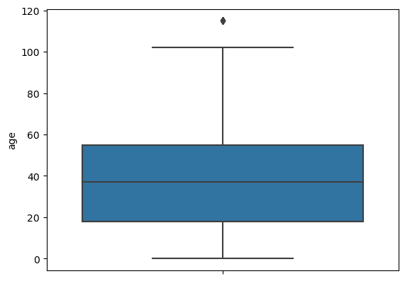

```python
sns.boxplot(y=df['age'])
```

*From the box plot, we observe that there is an outlier in our dataset. The percentile values for the variable are as follows:*

- The minimum age observed in the dataset is 0.00, indicating the presence of at least one patient with an age of zero or close to zero.
- The 25th percentile (25%) value is 18.00, which means that 25% of the patients have an age of 18 or below.
- The median (50%) value is 37.00, indicating that 50% of the patients have an age of 37 or below.
- The 75th percentile (75%) value is 55.00, suggesting that 75% of the patients have an age of 55 or below.

Furthermore, the presence of an outlier in the dataset is also noted, which implies that there is at least one patient with an age that significantly deviates from the majority of the other patients (115 years old). </i>

*Having identified the outlier age value, let's inspect our dataset to determine the number of patients who are 115 years old.*

```python
df.query('age>=115')
```

|  | patientid | appointmentid | gender | scheduledday | appointmentday | age | neighbourhood | scholarship | hipertension | diabetes | alcoholism | handcap | sms_received | no-show |
| --- | --- | --- | --- | --- | --- | --- | --- | --- | --- | --- | --- | --- | --- | --- |
| 63912 | 3.196321e+13 | 5700278 | F | 2016-05-16 09:17:44+00:00 | 2016-05-19 00:00:00+00:00 | 115 | ANDORINHAS | 0 | 0 | 0 | 0 | 1 | 0 | Yes |
| 63915 | 3.196321e+13 | 5700279 | F | 2016-05-16 09:17:44+00:00 | 2016-05-19 00:00:00+00:00 | 115 | ANDORINHAS | 0 | 0 | 0 | 0 | 1 | 0 | Yes |
| 68127 | 3.196321e+13 | 5562812 | F | 2016-04-08 14:29:17+00:00 | 2016-05-16 00:00:00+00:00 | 115 | ANDORINHAS | 0 | 0 | 0 | 0 | 1 | 0 | Yes |
| 76284 | 3.196321e+13 | 5744037 | F | 2016-05-30 09:44:51+00:00 | 2016-05-30 00:00:00+00:00 | 115 | ANDORINHAS | 0 | 0 | 0 | 0 | 1 | 0 | No |
| 97666 | 7.482346e+14 | 5717451 | F | 2016-05-19 07:57:56+00:00 | 2016-06-03 00:00:00+00:00 | 115 | SÃO JOSÉ | 0 | 1 | 0 | 0 | 0 | 1 | No |

*We observe that there are a total of 5 appointment entries in our dataset where the age values are greater than or equal to 115. To gain further insight into the distribution of this age group, we will inspect our dataset for unique patient IDs corresponding to appointments made by patients whose age is greater than or equal to 115 years, as follows:*

```python
df.query('age>=115')['patientid'].unique()
```

```
array([3.19632116e+13, 7.48234579e+14])
```

```python
len(df['patientid'].unique())
```

```
62298
```

*The query above returns two unique patient IDs, indicating that out of the 62,298 patients who scheduled appointments, only two of them had ages of 115 and above. Since the number of such cases is not substantial, it would be reasonable to simply drop these entries from the dataset rather than applying advanced outlier detection techniques.*

```python
df.drop(index=df.query('age>=115').index,axis=0,inplace=True,)
```

```python
df.query('age>=115')
```

|  | patientid | appointmentid | gender | scheduledday | appointmentday | age | neighbourhood | scholarship | hipertension | diabetes | alcoholism | handcap | sms_received | no-show |
| --- | --- | --- | --- | --- | --- | --- | --- | --- | --- | --- | --- | --- | --- | --- |

*Now that we have successfully dropped these entries, we will create a box plot to confirm that the outliers have been eliminated from the dataset.*

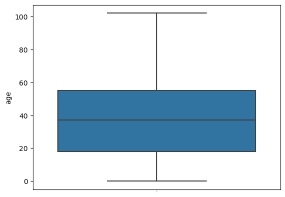

```python
sns.boxplot(y=df['age'])
```

*The age column has now been cleaned for outliers, allowing us to proceed with analyzing the data.*

## Step 3: Answering Analysis Questions

### **Q1. In general, what gender is associated with the highest no-show up rate?**

*To address this question, our approach will begin by examining the number of unique genders present in our dataset. Subsequently, we will determine the count of observations corresponding to each gender, allowing us to gain insights into the distribution of gender within our dataset.*

```python
df['gender'].value_counts()
```

```
F    71834
M    38687
Name: gender, dtype: int64
```

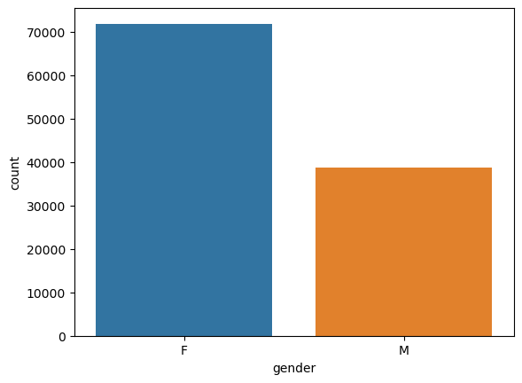

```python
sns.countplot(data=df,x='gender')
```

*Now, let's examine the number of patients who scheduled appointments but did not show up on the designated appointment day.*

*Having gained an understanding of the patient distribution across genders, we can now proceed to answer our question. This will involve grouping the data by gender and no-show status, resulting in a new dataframe that provides a comparative analysis of appointment attendance based on gender.*

```python
attendance=pd.DataFrame(df.groupby(by=['gender','no-show'],as_index=False).count()[['gender','no-show','patientid']])
attendance.columns=['gender','no-show','count']
attendance.head()
```

|  | gender | no-show | count |
| --- | --- | --- | --- |
| 0 | F | No | 57243 |
| 1 | F | Yes | 14591 |
| 2 | M | No | 30962 |
| 3 | M | Yes | 7725 |

When considering the cumulative missed patient appointments, male patients accounted for **34.612%** of all missed appointments, whereas female patients constituted **65.388%**. These proportions are visually represented in the clustered bar chart below:

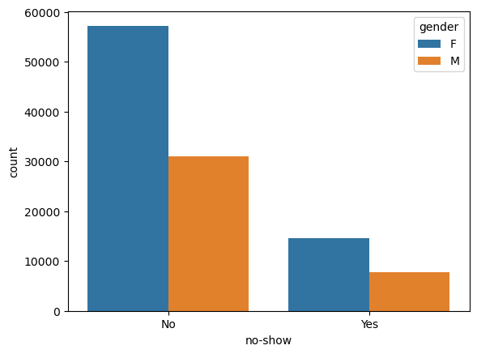

```python
sns.countplot(data=df,x='no-show',hue='gender')
```

[output not shown]

### **Q2. What age group is associated with the highest number of missed appointments?**

This question aims to investigate the relationship between a patient's age and their likelihood of showing up for an appointment. To address this, we will follow these steps:

```
1. Examine the statistical summary of the age column to determine appropriate age groups (bins) for our analysis.
2. Introduce a new column, "age_group," to categorize patients based on their age group.
3. Group the missed appointments based on the age_group and calculate the count of missed appointments for each age group.
4. Visualize the relationship between age groups and missed appointments using a pie chart.
```

Let's begin by examining the age column to gain an initial understanding of the patients' age distribution. </i>

```python
df['age'].describe()
```

```
count    110521.000000
mean         37.085694
std          23.104606
min           0.000000
25%          18.000000
50%          37.000000
75%          55.000000
max         102.000000
Name: age, dtype: float64
```

```
- child: Includes patients between 0 and 17 years old.
- Youth: Encompasses patients between 18 and 35 years old.
- Adult: Comprises patients between 36 and 55 years old.
- Elderly: Consists of patients above 55 years old.
```

By organizing the data into these age categories, we can better understand the distribution of patients across different age groups and assess any potential patterns or trends.

```python
# Creating labels and bins
labels='child,youth,adult,elderly'.split(',')
bins=[0,18,36,56,115]
# inserting age groups into our dataframe
df['age_group']=pd.cut(x=df['age'],bins=bins, labels=labels,right=False)
```

```python
df[['age','age_group']].sample(5)
```

|  | age | age_group |
| --- | --- | --- |
| 48834 | 60 | elderly |
| 10371 | 8 | child |
| 59418 | 10 | child |
| 80395 | 68 | elderly |
| 43015 | 10 | child |

*Now that we have successfully created an age group column based on the defined age brackets, we can proceed to calculate the number of missed patient appointments within each age group. This analysis will provide valuable insights into the attendance patterns and missed appointment rates across different age groups.*

```python
# grouping missed appointments by age_group
age_df=df.query('`no-show`=="Yes"').groupby('age_group',as_index=False).count()[['age_group','no-show']].sort_values(by='no-show',ascending=False,ignore_index=True)
age_df
```

|  | age_group | no-show |
| --- | --- | --- |
| 0 | youth | 6103 |
| 1 | child | 5997 |
| 2 | adult | 5916 |
| 3 | elderly | 4300 |

From the query above, we can observe that the youth age group had the highest number of missed patient appointments, totaling 6,103 appointments. The kid age group follows closely behind with 5,997 missed appointments, while the adult age group had 5,916 missed appointments. In contrast, the elderly age group had the lowest number of missed appointments, with a total of 4,300. This information provides insights into the distribution of missed patient appointments across different age groups and it can be visualized as follows:

```python
df.query('`no-show`=="Yes"').groupby(by='age_group',as_index=False).count()[['age_group','no-show']].iplot(kind='bar',x='age_group',y='no-show',xTitle="patient's Age Group",yTitle='No. of Missed Appointments',title='Number of Missed Patient Appointments by Age Group',color='blue')
```

[interactive chart not shown]

This can also be represented on a pie chart as follows: </i>

```python
df_missed_appointments = df.query('`no-show` == "Yes"').groupby(by='age_group', as_index=False).count()
fig = px.pie(df_missed_appointments, values='no-show', names='age_group', labels=['Child', 'Youth', 'Adult', 'Elderly'],title=
"Percentage of Missed Appointments by Age Group")
fig.update_layout(legend_title='Age Group')
fig.show()
```

[interactive chart not shown]

*Based on the previous queries on missed appointments by age group, the age bracket associated with the highest number of missed appointments is the youth age group as it had a total of 6,103 missed appointments, which is the highest among all age groups.*

### **Q3. What day of the week registered the highest number of missed appointments?**

*To answer this question, we will feature engineer a new column called "week_day" to represent the day of the week when an appointment was scheduled to happen. We will group all the missed appointments by week_day and compare their count to identify which day had the highest number of missed appointments.*

To begin, let's create the "week_day" column. </i>

```python
df['week_day']=df['appointmentday'].apply(lambda x:x.strftime('%A'))
df['week_day'].value_counts().sort_values(ascending=False)
```

```
Wednesday    25867
Tuesday      25640
Monday       22712
Friday       19018
Thursday     17245
Saturday        39
Name: week_day, dtype: int64
```

*From the above query, we observe the number of appointments booked on each day of the week. The distribution is as follows:*

1. Wednesday: 25,867 appointments
2. Tuesday: 25,640 appointments
3. Monday: 22,712 appointments
4. Friday: 19,018 appointments
5. Thursday: 17,245 appointments
6. Saturday: 39 appointments

These values indicate the total count of appointments scheduled for each respective day of the week. This relationship can be visualized using a bar chart as follows: </i>

```python
df.groupby(by='week_day',as_index=False).count().sort_values(by='no-show',ascending=False)[['week_day','no-show']].iplot(kind='bar',x='week_day',y='no-show',xTitle='Day of The Week',yTitle='Number of Scheduled Appointments',title=
"Number of Appointments Booked per Day of the Week",color='blue')
```

[interactive chart not shown]

*The analysis of appointment bookings reveals interesting insights about the distribution of appointments across different days of the week. Among the weekdays, Wednesday and Tuesday appear to have the highest number of appointments scheduled, followed by Monday and Friday. Thursday falls slightly behind in terms of appointment bookings. Interestingly, Saturday has a significantly lower number of appointments compared to the weekdays, indicating a reduced demand for appointments on weekends. This pattern suggests that patients prefer scheduling their appointments during weekdays, with Wednesday and Tuesday being the most popular choices*

*Now that we have understood the distribution of appointments in each respective weekday, let us proceed to examine the distribution of missed appointments across each weekday. In this analysis, our focus will solely be on missed appointments to determine if there is any variation in the number of missed appointments on different days. Our objective is to identify which day exhibits the highest number of missed appointments. We will adopt a similar approach as described earlier, grouping the missed appointments by weekday and comparing their counts to draw meaningful conclusions*

```python
df[df['no-show']=='Yes'].groupby(by='week_day',as_index=False).count().sort_values(by='no-show',ascending=False,ignore_index=True)[['week_day','no-show']]
```

|  | week_day | no-show |
| --- | --- | --- |
| 0 | Tuesday | 5152 |
| 1 | Wednesday | 5093 |
| 2 | Monday | 4689 |
| 3 | Friday | 4037 |
| 4 | Thursday | 3336 |
| 5 | Saturday | 9 |

```python
df[df['no-show']=='Yes'].groupby(by='week_day',as_index=False).count().sort_values(by='no-show',ascending=False,ignore_index=True)[['week_day','no-show']].iplot(kind='bar',x='week_day',y='no-show',xTitle='Day of The Week',yTitle='Number of Missed Appointments',color='blue',title='Missed Appointments by Day of the Week')
```

[interactive chart not shown]

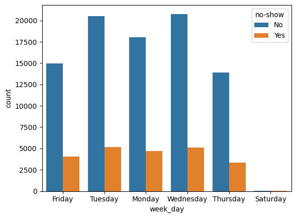

```python
sns.countplot(data=df,x='week_day',hue='no-show')
```

### **Q4. What are the 5 leading hospital neighborhoods in alcoholism cases? How do these neighborhoods compare in terms of missed patient appointments?**

*To address this question, we will follow the following steps:*

1. **Determine the number of unique hospital neighborhoods.**

   We will identify and count the distinct hospital neighborhoods present in the dataset.
2. **Create a dataframe containing all the alcoholic patients**

   We will filter the dataset to create a new dataframe specifically focused on patients diagnosed with alcoholism.
3. **Group alcoholic patients with relation to hospital regions**

   We will group the alcoholic patients in the new dataframe based on the hospital neighborhoods they belong to. This will allow us to analyze the distribution of alcoholism cases across different regions.
4. **Plot the relationship.**

   We will visualize the relationship between hospital neighborhoods and alcoholism cases using an appropriate plot, such as a bar chart or a map. This visualization will provide insights into the five leading hospital neighborhoods in terms of alcoholism cases and allow for comparisons among these neighborhoods in relation to missed patient appointments. </i>

```python
# step 1: checking for the number of unique neighborhoods in our dataset
df['neighbourhood'].nunique()
```

```
81
```

*Now that we have determined that our dataset contains 81 different regions, we will proceed to group the alcoholic patients based on their respective neighborhoods. This grouping will enable us to analyze the distribution of alcoholism cases among different regions in our dataset.*

```python
#step 2: Creating a dataframe containing alcoholic patients
alcoholism_df=df.query('alcoholism == 1')
alcoholism_df.shape
```

```
(3360, 16)
```

```python
#step 3: Grouping alcoholic patients by their neighborhoods
alcoholism_df.groupby('neighbourhood').count()['alcoholism'].sort_values(ascending=False)[:5]
```

```
neighbourhood
SANTA MARTHA    344
DA PENHA        172
BONFIM          166
SÃO PEDRO       150
ROMÃO           125
Name: alcoholism, dtype: int64
```

*Based on the obtained results, the regions that are leading in alcoholism cases are as follows:*

```
1. SANTA MARTHA: This region has recorded 344 cases of alcoholism.
2. DA PENHA: The region of DA PENHA has reported 172 cases of alcoholism.
3. BONFIM: BONFIM has identified 166 cases of alcoholism.
4. SÃO PEDRO: SÃO PEDRO has documented 150 cases of alcoholism.
5. ROMÃO: The region of ROMÃO has reported 125 cases of alcoholism.
```

These regions have the highest numbers of alcoholism cases based on the data provided. </i>

*Now that we have identified the top 5 hospital regions with reported cases of alcoholism, we will proceed to compare the number of patients who did not show up for their appointments in these regions. This analysis will provide insights into the attendance patterns and potential correlations between alcoholism cases and missed appointments in these specific regions*

```python
top5_comparison=df.query('neighbourhood ==["SANTA MARTHA","DA PENHA","BONFIM","SÃO PEDRO","ROMÃO"]').query('`no-show`=="Yes"').groupby('neighbourhood',as_index=False).count()[['neighbourhood','no-show']].sort_values(by='no-show',ascending=True)
top5_comparison
```

|  | neighbourhood | no-show |
| --- | --- | --- |
| 1 | DA PENHA | 429 |
| 2 | ROMÃO | 474 |
| 3 | SANTA MARTHA | 496 |
| 4 | SÃO PEDRO | 515 |
| 0 | BONFIM | 550 |

*The top 5 neighborhoods with reported cases of alcoholism have the following rankings in terms of missed patient appointments:*

[output not shown]

Comparing these numbers to the previous query on alcoholism cases, we can observe that there is variation in the ranking order. This indicates that while certain regions may have a higher number of reported alcoholism cases, the number of missed patient appointments may not necessarily follow the same order. This variation highlights the complex relationship between alcoholism cases and patient attendance, emphasizing the need for further analysis to understand the factors influencing missed appointments in each neighborhood.

The comparison can be visually represented through a plot, which will provide a clear visualization of the differences in missed patient appointments among these top 5 alcoholism neighborhoods. </i>

```python
top5_comparison.iplot(kind='bar',x='neighbourhood',y='no-show',colors='blue',title='Comparison of Missed Patient Appointments in Top 5 Alcoholism Neighborhoods',xTitle='Neighborhood',yTitle='No. of Missed Appointments')
```

[interactive chart not shown]

### **Q5. Is there a correlation between the number of days a patient in a given region has to wait for an appointment and the number of missed appointments in that particular region?**

*To further investigate the high rates of missed appointments in these regions, we can create a new column called "waiting_time" that records the number of days a patient has to wait for an appointment. By doing so, we can calculate the average waiting time for each hospital neighborhood. This will allow us to explore whether there is a relationship between the waiting time and the number of missed appointments in each neighborhood.*

Analyzing this relationship can provide valuable insights into the potential impact of waiting time on appointment attendance and help identify any patterns or correlations that may exist

We will begin by creating a new column named 'waiting_time' to capture the difference between the date a patient schedules their appointment and the actual appointment day. This new column will provide us with the duration of time that patients have to wait before their scheduled appointments. </i>

```python
#Lets create another column showing how many days patients have to wait for an appointment
time_diff=df['appointmentday']-df['scheduledday']
days_count=[]
for entries in time_diff:
    days=(np.timedelta64(entries,'ns').astype('timedelta64[D]'))/np.timedelta64(1, 'D')
    days_count.append(days)
df['waiting_time']=days_count
```

```python
# Checking for statistical summary of the waiting_time column
df['waiting_time'].describe()
```

```
count    110521.000000
mean          9.183721
std          15.255082
min          -7.000000
25%          -1.000000
50%           3.000000
75%          14.000000
max         178.000000
Name: waiting_time, dtype: float64
```

```python
df['waiting_time'].describe()
```

```
count    110521.000000
mean          9.183721
std          15.255082
min          -7.000000
25%          -1.000000
50%           3.000000
75%          14.000000
max         178.000000
Name: waiting_time, dtype: float64
```

```python
# finding the average waiting time for each of the neighbourhoods
mean_waiting=df.query('`no-show`=="Yes"').groupby('neighbourhood').mean(numeric_only=True)['waiting_time']
hood_no_show=df.query('`no-show`=="Yes"').groupby('neighbourhood').count()['no-show']
# checking for correlation between waiting_time and missed appointments
round(hood_no_show.corr(mean_waiting),4)
```

```
0.222
```

*The analysis reveals a weak positive correlation of **0.222** between the number of missed appointments and the waiting time for patients to secure an appointment. This correlation coefficient suggests that there is a slight tendency for an increase in missed appointments as the waiting time for appointments also increases. However, the correlation is relatively weak, indicating that other factors may have a more significant influence on missed appointments.*

### **Q5. Can a model be built to predict if a patient will show up for an appointment?**

*Under this section, we are going to build a logistic regression model to predict whether a patient will show up for their appointment or not. The analysis will involve the following variables:*

**Dependent Variable**: "no-show"

These independent variables represent various patient attributes that may influence their decision to show up for the appointment. By examining the coefficients derived from the logistic regression model, we can identify which attributes have the most impact on patients missing their appointments. This analysis aims to provide insights into the key factors that contribute to appointment no-shows and help healthcare providers optimize their strategies for improving attendance rates.</i>

We will start by preparing our dataset for modelling. Since we already have already feature engineered all the required variables, we will just proceed and drop all the columns that we don't need, namely: patientid,appointmentid,scheduleday,appointmentday,age,neighborhood

```python
df.drop(columns='patientid,appointmentid,appointmentday,scheduledday,neighbourhood,age,age_group,waiting_time,handcap'.split(','),axis=1,inplace=True,)
```

```python
df.head(3)
```

|  | gender | scholarship | hipertension | diabetes | alcoholism | sms_received | no-show | week_day |
| --- | --- | --- | --- | --- | --- | --- | --- | --- |
| 0 | F | 0 | 1 | 0 | 0 | 0 | No | Friday |
| 1 | M | 0 | 0 | 0 | 0 | 0 | No | Friday |
| 2 | F | 0 | 0 | 0 | 0 | 0 | No | Friday |

```python
df=pd.get_dummies(data=df,columns='no-show,gender,scholarship,diabetes,alcoholism,sms_received,week_day,hipertension'.split(','),drop_first=True)
```

```python
df.head()
```

|  | no-show_Yes | gender_M | scholarship_1 | diabetes_1 | alcoholism_1 | sms_received_1 | week_day_Monday | week_day_Saturday | week_day_Thursday | week_day_Tuesday | week_day_Wednesday | hipertension_1 |
| --- | --- | --- | --- | --- | --- | --- | --- | --- | --- | --- | --- | --- |
| 0 | 0 | 0 | 0 | 0 | 0 | 0 | 0 | 0 | 0 | 0 | 0 | 1 |
| 1 | 0 | 1 | 0 | 0 | 0 | 0 | 0 | 0 | 0 | 0 | 0 | 0 |
| 2 | 0 | 0 | 0 | 0 | 0 | 0 | 0 | 0 | 0 | 0 | 0 | 0 |
| 3 | 0 | 0 | 0 | 0 | 0 | 0 | 0 | 0 | 0 | 0 | 0 | 0 |
| 4 | 0 | 0 | 0 | 1 | 0 | 0 | 0 | 0 | 0 | 0 | 0 | 1 |

```python
df.dtypes
```

```
no-show_Yes           uint8
gender_M              uint8
scholarship_1         uint8
diabetes_1            uint8
alcoholism_1          uint8
sms_received_1        uint8
week_day_Monday       uint8
week_day_Saturday     uint8
week_day_Thursday     uint8
week_day_Tuesday      uint8
week_day_Wednesday    uint8
hipertension_1        uint8
dtype: object
```

```python
import sklearn
y=df['no-show_Yes'] # independent variable

independent_vars=list(df.columns)
independent_vars.remove('no-show_Yes')

x=df[independent_vars]
```

*Next, our focus will be on preparing our data for modeling by addressing the class imbalance in the dataset. To tackle this issue, we will employ the undersampling technique. By strategically reducing the instances of the majority class, we aim to create a more balanced dataset that accurately represents the distribution of classes. This step is crucial in ensuring that our models receive adequate training on both minority and majority classes, leading to more accurate predictions and better overall performance. The class imbalance in our dataset can be shown using a bar chart as follows;*

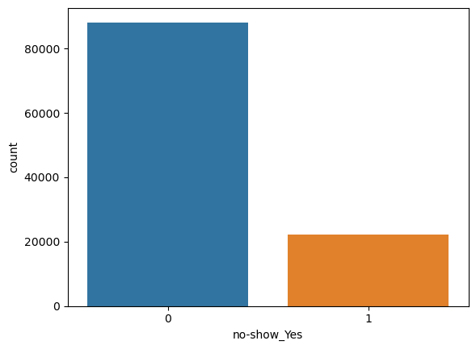

```python
sns.countplot(x=df['no-show_Yes'])
```

*We will utilize the 'imblearn' module, a powerful tool specifically designed for handling imbalanced datasets, to perform the aforementioned task.By leveraging the capabilities of 'imblearn', we can efficiently apply the undersampling technique and optimize our dataset as shown below.*

```python
import imblearn
from imblearn.under_sampling import RandomUnderSampler
ran_sampler=RandomUnderSampler(replacement=True)
x_s,y_s=ran_sampler.fit_resample(x,y)
```

*Next, we will split our data into training and test sets. The training data will be used to fit our logistic regression model, while the test data will be used to evaluate the accuracy and performance of our model. This step ensures that we can assess how well our model generalizes to unseen data. By checking the accuracy of our model on the test data, we can gain insights into its predictive capabilities and assess its overall performance.*

```python
from sklearn.model_selection import train_test_split
x_train,x_test,y_train,y_test=train_test_split(x_s,y_s,train_size=0.80)
```

*With our data split into training and testing sets, we will proceed to fit our logistic regression model. The fitting process involves training the model on the training data, allowing it to learn the relationships between the predictor variables and the target variable. By fitting the model, we aim to estimate the coefficients for each predictor variable, which will enable us to make predictions on new, unseen data. The fitted model will capture the patterns and associations within the training data, enabling it to generalize and make predictions on the test data accurately*

```python
from sklearn.linear_model import LogisticRegression
logmodel=LogisticRegression()
logmodel.fit(x_train,y_train)
```

```
LogisticRegression()
```

*After fitting our logistic regression model, we will now proceed to test it on the previously separated test data. Testing the model involves applying it to the test data to make predictions on whether a patient will show up for their appointment. By comparing these predictions with the actual values from the test data, we can assess the performance and accuracy of our model. This step allows us to evaluate how well our logistic regression model generalizes to new, unseen data and provides insights into its predictive capabilities*

```python
from sklearn import metrics
prediction=logmodel.predict(x_test)
performance_report=metrics.classification_report(y_true=y_test,y_pred=prediction)
#performance_report = metrics.classification_report(y_true=y_test, y_pred=prediction, zero_division=1) # Eliminates the error but it does not fix the prediction issue

print(performance_report)
```

```
              precision    recall  f1-score   support

           0       0.56      0.69      0.62      4470
           1       0.59      0.46      0.52      4457

    accuracy                           0.57      8927
   macro avg       0.58      0.57      0.57      8927
weighted avg       0.58      0.57      0.57      8927
```

```python
from sklearn.metrics import precision_score, recall_score, f1_score

# Example calculation with zero_division parameter
precision = round(precision_score(y_test, prediction, average='macro', zero_division=1),3)
recall = round(recall_score(y_test, prediction, average='macro', zero_division=1),3)
f1 = round(f1_score(y_test, prediction, average='macro', zero_division=1),3)

print('Precision: {}\nRecall: {}\nF1 Score: {}'.format(precision,recall,f1))
```

```
Precision: 0.576
Recall: 0.572
F1 Score: 0.566
```

```python
print(metrics.confusion_matrix(prediction,y_test)) # confusion matrix
```

```
[[3068 2419]
 [1402 2038]]
```

```python
coeff=pd.DataFrame(data=logmodel.coef_[0],columns=['Coefficient Value'],index=x.columns).sort_values(by='Coefficient Value',ascending=False)
coeff
```

|  | Coefficient Value |
| --- | --- |
| sms_received_1 | 0.668315 |
| scholarship_1 | 0.190872 |
| diabetes_1 | 0.016083 |
| gender_M | 0.007308 |
| alcoholism_1 | 0.002204 |
| week_day_Saturday | -0.074292 |
| week_day_Monday | -0.153632 |
| week_day_Thursday | -0.203260 |
| hipertension_1 | -0.237891 |
| week_day_Wednesday | -0.257780 |
| week_day_Tuesday | -0.258424 |

## **Conclusion**

### **Limitations:**

These limitations highlight areas where additional data or improvements in data collection could enhance the analysis and provide more comprehensive insights.

```
1. The dataset did not provide information on how far patients were located from the hospital neighborhood. This missing information could be valuable in determining if the distance patients have to travel to get an appointment influences their likelihood of showing up. The proximity factor could potentially impact appointment attendance rates.

2. The dataset exhibited inconsistencies in capturing the dates when appointments were scheduled and the actual appointment dates. This inconsistency led to the presence of negative values when calculating the waiting time for patients. Such inconsistencies can affect the accuracy of analyzing the relationship between waiting time and missed appointments.
```

### **Business Applications:**

These applications demonstrate how the machine learning model predicting patient attendance can be applied in various industries beyond healthcare, enabling businesses to optimize their operations and enhance customer experience.

```
1. Healthcare Service Providers: Healthcare facilities can utilize the insights from the analysis to develop targeted strategies and interventions to reduce missed appointments. They can implement reminder systems, tailored communication, or appointment rescheduling options to improve patient attendance.

2. Hospitality Industry: Hotels, restaurants, and other service-based industries that rely on customer reservations can benefit from the analysis. By implementing a similar prediction model, they can anticipate the likelihood of no-shows for reservations and optimize resource allocation accordingly, minimizing operational disruptions.

3. Insurance Providers: Insurance companies can leverage the predictive model to assess the risk of missed appointments for policyholders. This information can help insurance providers tailor their coverage plans, premiums, and policy terms based on the likelihood of missed appointments, ultimately improving the overall efficiency of healthcare insurance.

4. Appointment Scheduling Platforms: Companies offering appointment scheduling platforms can integrate a prediction model based on the analysis. This would help clients optimize their schedules by identifying high-risk appointments and allocating resources accordingly.

5. Transportation Services: Businesses providing transportation services to clients for appointments, such as medical transportation companies, can use the prediction model to optimize their resources. By identifying appointments with a high probability of being missed, they can prioritize and allocate transportation services more efficiently.
```